# Aside

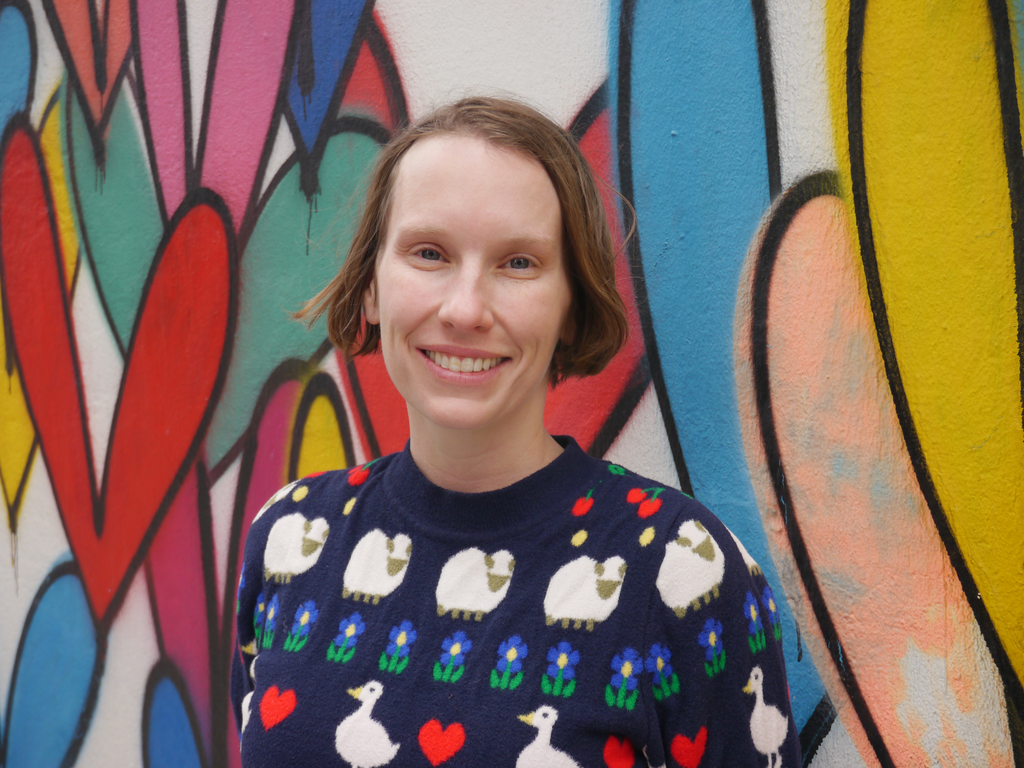

View this CV online with links at maraalexeev.github.io/cv/

## Contact

- mara.alexeev@gmail.com
- MaraAlexeev
- maraalexeev.com
- [maraalexeev](https://www.linkedin.com/in/maraalexeev/)

## Language Skills

Spreadsheets

R

SQL

Python

English

Русский

Deutsch

ASL

Latin

## Credits

Made with the R packages [**pagedown**](https://github.com/rstudio/pagedown) and [**datadrivencv**](https://github.com/nstrayer/datadrivencv).

Last updated on 2025-07-26.

# Main

## Mara Alexeev, MD, MBI, MPH

## Currently Learning and Doing

### Data Tools

Snowflake, AWS Redshift and Sagemaker, Hex, dbt

### EMR and HIT Experience

Epic, Cerner, Allscripts, GE Muse (ECG), DICOM data

### Terminologies, Vocabularies, and Ontologies

ICD-10, LOINC, SNOMED CT, CPT Codes, Human Phenotype Ontology

## Graduate Medical Education

### Clinical Informatics Fellow

Boston Children’s Hospital

Boston, MA

2022 - 2020

- Consulted for Division of Developmental Medicine to create clinical-care-to-research data pipeline that pulled directly from free text notes generated at point of care
- Updated newborn history data collection system and developed reusable data elements for clinical use as well as future research use
- Explored and advised on applications of NLP with Business Intelligence group
- Helped create BCRP Residency Handbook using the R bookdown package
- Conducted workflow analysis of complex transfer process of ICU patients
- Implemented optimization project of Cerner’s Launchpoint within Primary Care Clinic to improve patient flow, staff communication, and rapid order entry
- Part of Organizing Committee for R/Medicine Conference<sup>3</sup> in 2020 and 2021

### Pediatric Chief Resident

Memorial Sloan Kettering Cancer Center

New York City, NY

2020 - 2019

### Pediatrics Internship and Residency

Kaiser Oakland Medical Center

Oakland, CA

2015 - 2012

- Diagnosed measles and alerted CDPH for *first* identified case in the 2015 US (Disneyland) outbreak within minutes of presentation and having never seen an in-person case previously

## Education

### Master of Biomedical Informatics<sup>4</sup>

Harvard Medical School  
NLM Biomedical Informatics Research and Data Science Fellow

Boston, MA

2022 - 2020

### Masters of Public Health

*Interdisciplinary*  
University of California, Berkeley

Berkeley, CA

2016 - 2015

### MD

*Teaching Distinction Track*  
University of Iowa

Iowa City, IA

2012 - 2008

### BS in Biochemistry

*Summa Cum Laude*  
Iowa State University

Ames, IA

2008 - 2004

- Minors in Mathematics, German, and Russian Studies
- Attended on full ride scholarship as a National Merit Scholar

## Medical Work Experience

### Urgent Care Pediatrician

Boston Children’s Hospital Primary Care Clinic

Boston, MA

2022 - 2020

- Provided in person and virtual visits for pediatric patients of all ages

### Field Physician for School District 22 in Brooklyn

NYC Department of Health and Mental Hygiene

New York City, NY

2018 - 2017

### Outpatient Pediatrician

Hawaii Permanente Medical Group

Wailuku, HI

2017 - 2016

- Successfully managed critical airway in outpatient setting
- Identified extremely rare hematological condition and managed case with multiple subspecialists in O‘ahu
- Diagnosed Kawaski Disease despite uncommon presentation without initial fevers

## Medical Credentials

### Medical Licenses

New York State Medical License since 2017, active

### Certifications

ABP Board Certification in Pediatrics since 2015  
ABPM Board Certification in Clinical Informatics since 2023

## Awards and Honors

### Gold Humanism Honor Society<sup>5</sup> *2012*

University of Iowa Carver College of Medicine

Iowa City, IA

### Robert Stupka Memorial Scholarship<sup>6</sup> *2007*

Iowa State University  
Department of Biochemistry, Biophysics, and Molecular Biology  
*For leadership and research excellence*

Ames, IA

## About Me

### Personal Tidbits

Enjoy cooking — ask me about my SQL recipe database  
Voracious reader  
Amazing SET player  
Over [7 year streak on Duolingo](https://www.duolingo.com/profile/Mara810169)  
Grew up on a working farm  
Traveled to 48 US states; missing AK, MI  
Favorite gift ever: a set of cordless power tools  
Met my future husband at Canada/USA Mathcamp

## Links

1. https://www.layerhealth.com/
2. https://dandelionhealth.ai/
3. https://r-medicine.org/
4. https://dbmi.hms.harvard.edu/people/mara-alexeev
5. https://medicine.uiowa.edu/md/supporting-students/gold-humanism-honor-society/class-2012-inductees
6. https://stupka.bb.iastate.edu/stupka-scholars/